# How to avoid overplotting

How to avoid overplotting

*A collection of common dataviz caveats by Data-to-Viz.com*

[figure not shown]

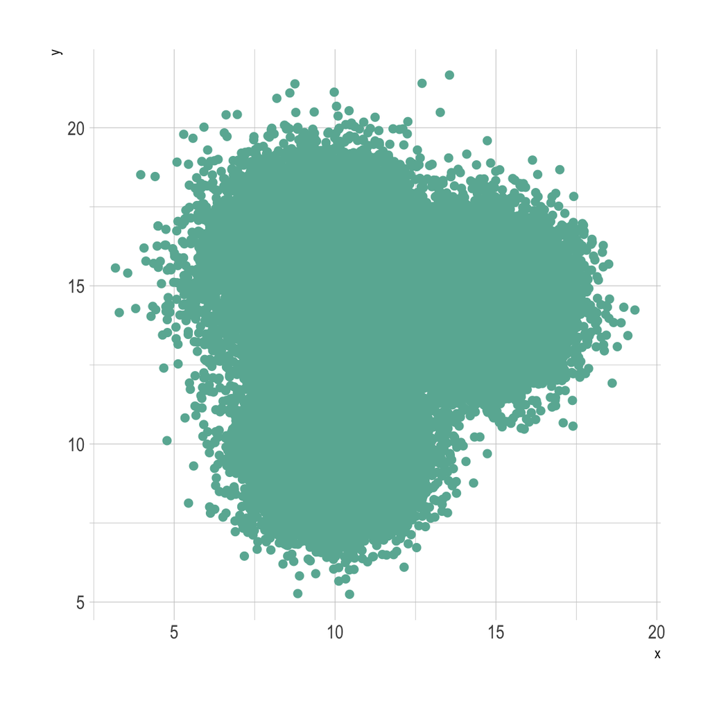

```r
# Libraries
library(tidyverse)
library(hrbrthemes)
library(viridis)
library(patchwork)

# Dataset:
a <- data.frame( x=rnorm(20000, 10, 1.2), y=rnorm(20000, 10, 1.2), group=rep("A",20000))
b <- data.frame( x=rnorm(20000, 14.5, 1.2), y=rnorm(20000, 14.5, 1.2), group=rep("B",20000))
c <- data.frame( x=rnorm(20000, 9.5, 1.5), y=rnorm(20000, 15.5, 1.5), group=rep("C",20000))
data <- do.call(rbind, list(a,b,c))

data %>%
  ggplot( aes(x=x, y=y)) +
    geom_point(color="#69b3a2", size=2) +
    theme_ipsum() +
    theme(
      legend.position="none"
    )
```

Overplotting is a common issue in dataviz. When your dataset is large, the dots of your scatterplot will tend to overlap, making the graphic unreadable.  
This issue is illustrated in the scatterplot below. A first look might lead to the conclusion that there is no obvious relationship between X and Y. We will see below how wrong this conclusion would be.  
In this post, I suggest 10 workarounds to avoid overplotting.

# Decreasing dot size

The easiest workaround is probably to `reduce dot size`. Depending on the quantity of overlap you have, it can give a really satisfying result. Here it appears clearly that 3 clusters are present, which was hidden in the previous figure.

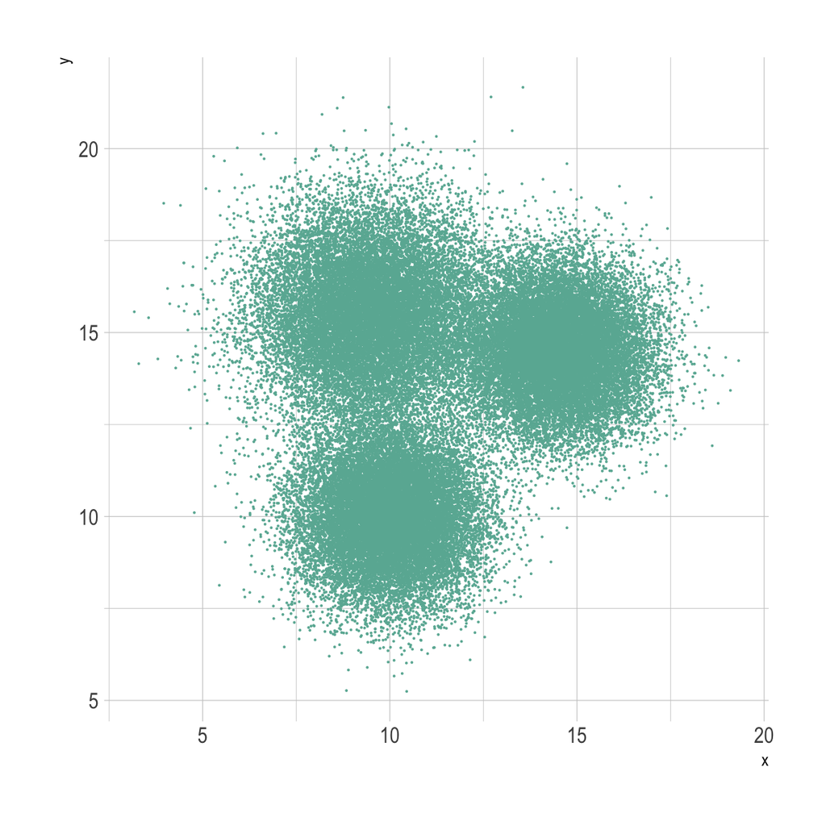

```r
# Plot with small dot size
data %>%
  ggplot( aes(x=x, y=y)) +
    geom_point(color="#69b3a2", size=0.02) +
    theme_ipsum() +
    theme(
      legend.position="none"
    )
```

# Transparency

In combination with decreasing dot size, using transparency also allows you to reveal patterns encountering overplotting issues:

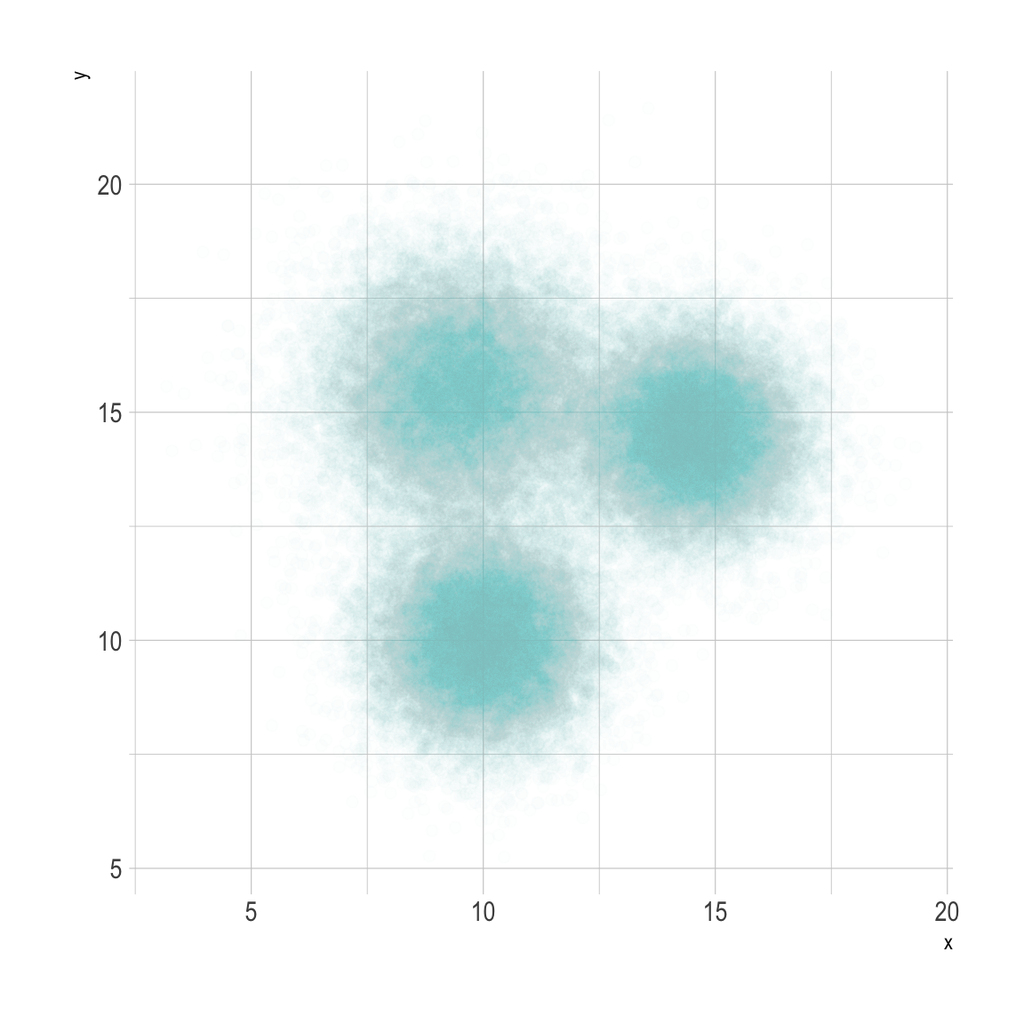

```r
# Plot with small dot size
data %>%
  ggplot( aes(x=x, y=y)) +
    geom_point(color="#69b3a2", size=2, alpha=0.01) +
    theme_ipsum() +
    theme(
      legend.position="none"
    )
```

# 2D density

The 2D density chart basically counts the number of observations within a particular area of the 2D space and represents this count by a color. If you divide the space into several squares, you get a 2D histogram. If you use hexagons instead of squares, you get a hexbin plot. You can also calculate a density estimate and represent 2D density plots or Contour plots. You can read more about this on the dedicated page of data-to-viz.com.

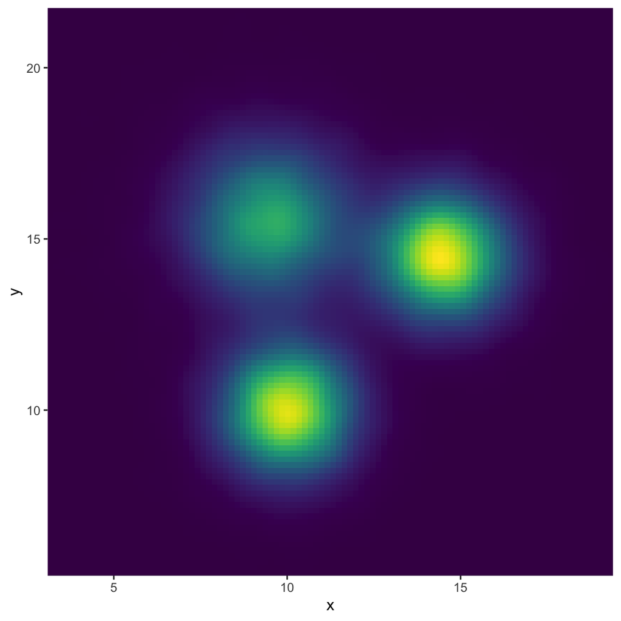

```r
ggplot(data, aes(x=x, y=y) ) +
  stat_density_2d(aes(fill = ..density..), geom = "raster", contour = FALSE) +
  scale_x_continuous(expand = c(0, 0)) +
  scale_y_continuous(expand = c(0, 0)) +
  scale_fill_viridis() +
  theme(
    legend.position='none'
  )
```

# Sampling

Sometimes less is more. Plotting only a fraction of your data (5% here) can greatly reduce the computing time and can help to avoid overplotting:

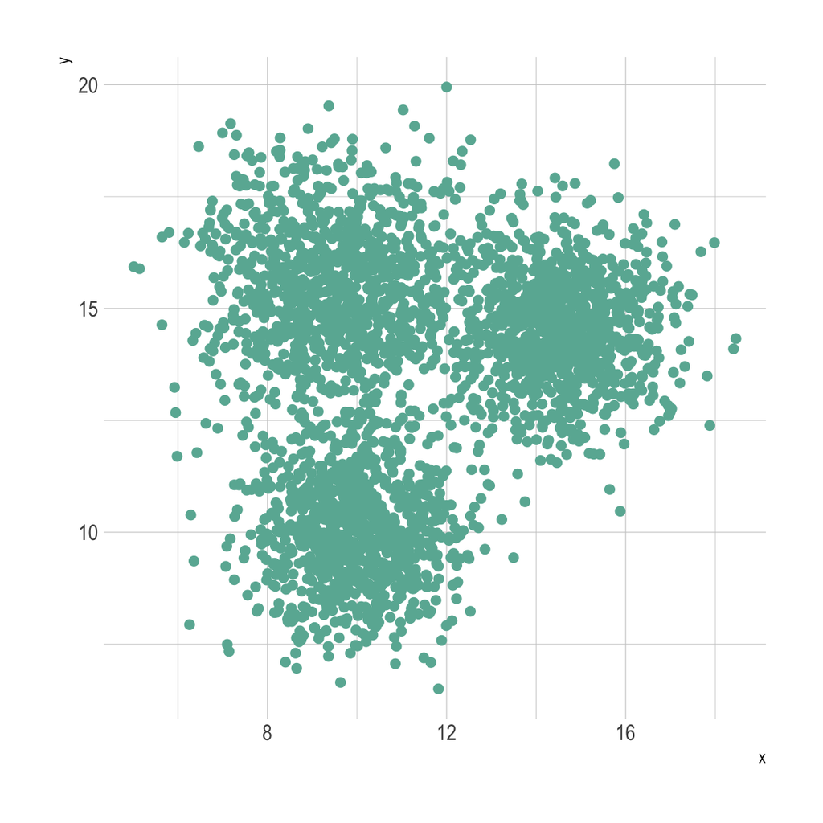

```r
# Plot with small dot size
data %>%
  sample_frac(0.05) %>%
  ggplot( aes(x=x, y=y)) +
    geom_point(color="#69b3a2", size=2) +
    theme_ipsum() +
    theme(
      legend.position="none"
    )
```

# Highlighting a group

Another way to reduce the complexity of a graphic is to highlight a specific group. (This suggests that you have a grouping variable in your dataset).

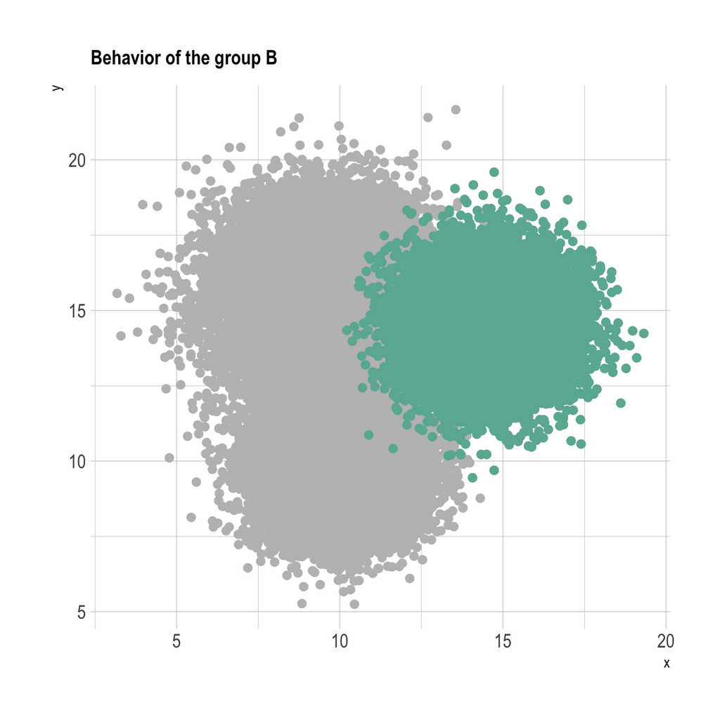

```r
# Plot with small dot size
data %>%
  ggplot( aes(x=x, y=y)) +
    geom_point(color="grey", size=2) +
    geom_point(data = data %>% filter(group=="B"), color="#69b3a2", size=2) +
    theme_ipsum() +
    theme(
      legend.position="none",
      plot.title = element_text(size=12)
    ) +
    ggtitle('Behavior of the group B')
```

# Grouping

If you have a grouping variable, it is highly recommended to make it appear on the graphic. In the case of overplotting, it can also help to reveal patterns.

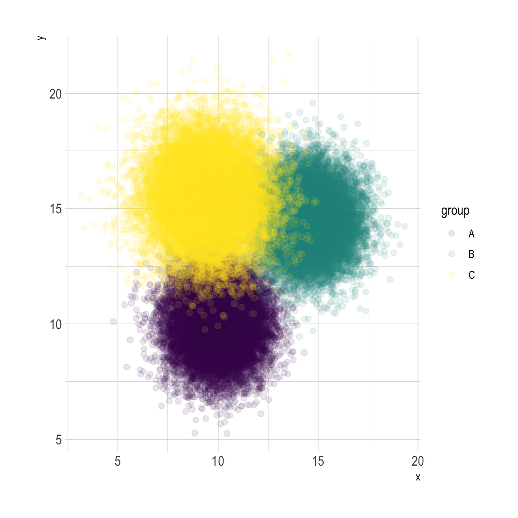

```r
# Plot with small dot size
data %>%
  ggplot( aes(x=x, y=y, color=group)) +
    geom_point( size=2, alpha=0.1) +
    scale_color_viridis(discrete=TRUE) +
    theme_ipsum()
```

# Faceting

As soon as you have several groups in your plot, an alternative is to use faceting: the same plot is repeated, each time highlighting another group:

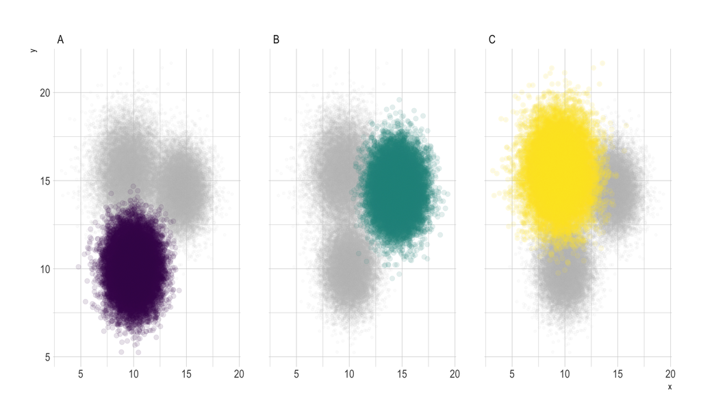

```r
# Plot with small dot size
data %>%
  ggplot( aes(x=x, y=y)) +
    geom_point( data=data %>% select(-group), size=1, alpha=0.05, color="grey") +
    geom_point( aes( color=group) , size=2, alpha=0.1) +
    scale_color_viridis(discrete=TRUE) +
    theme_ipsum() +
    theme(
      legend.position="none",
    ) +
    facet_wrap(~group)
```

# Jittering

`Jittering` is an option when one of the axis is qualitative (like 1, 2, 3.., see left figure). It adds or subtracts a random value to each data point to avoid overplotting. Note that other chart types are available in that kind of situation, like boxplot or violin plot.

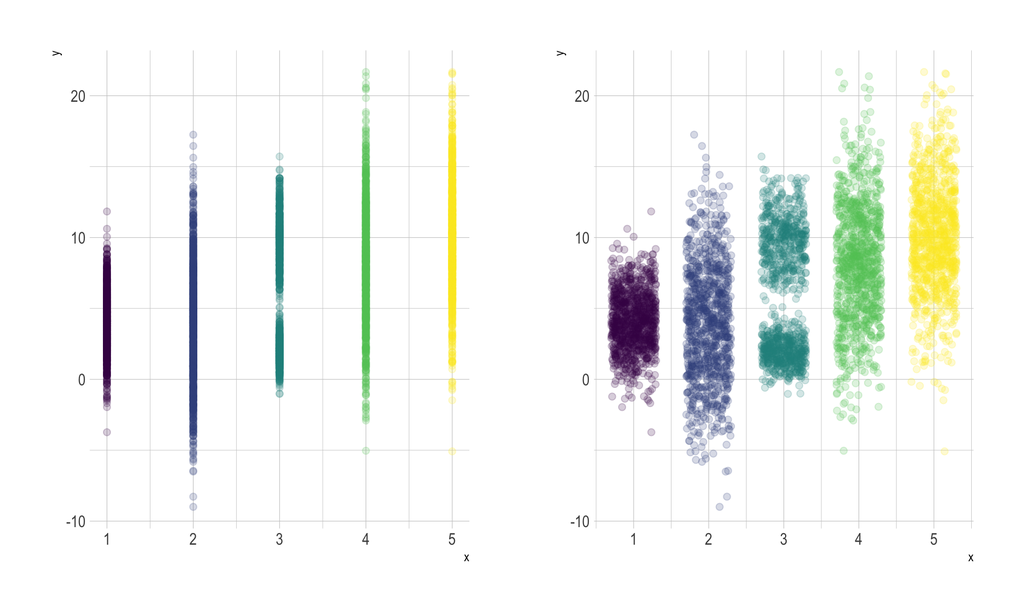

```r
# Create data
don <- data.frame(
  x = rep(seq(1,5), each=1000),
  y = c( rnorm(1000, 4, 2), rnorm(1000, 4, 4), rnorm(500, 2, 1), rnorm(500, 10, 2), rnorm(1000, 8, 4), rnorm(1000, 10, 4))
)

# basic plot
p1 <- don %>%
  ggplot( aes(x=x, y=y)) +
    geom_point( aes( color=x) , size=2, alpha=0.2) +
    scale_color_viridis() +
    theme_ipsum() +
    theme(
      legend.position="none",
    )

# Plot with jitter
p2 <- don %>%
  ggplot( aes(x=x, y=y)) +
    geom_jitter( aes( color=x) , size=2, alpha=0.2, width=0.3) +
    scale_color_viridis() +
    theme_ipsum() +
    theme(
      legend.position="none",
    )

p1 + p2
```

# 3D

As for 2d density plots, it is possible to transform the scatter plot information in a grid, and count the number of data points on each position of the grid. Then, instead of representing this number by a graduating color, the surface plot uses 3d to represent density. In this case, the position of the 3 groups become obvious:

```r
library(plotly)
library(MASS)

# Compute kde2d
kd <- with(data, MASS::kde2d(x, y, n = 50))

# Plot with plotly
plot_ly(x = kd$x, y = kd$y, z = kd$z) %>% add_surface()
```

[interactive chart not shown]

# Marginal distribution

Adding marginal distributions allow you to detect the distribution hidden in the overplotted parts of the graphic. You can add a boxplot, a histogram or a density plot in the margins.

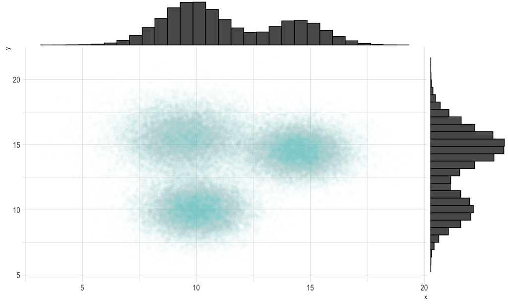

```r
library(ggExtra)

# create a ggplot2 scatterplot
p <- data %>%
  ggplot( aes(x=x, y=y)) +
    geom_point(color="#69b3a2", size=2, alpha=0.01) +
    theme_ipsum() +
    theme(
      legend.position="none"
    )

# add marginal histograms
ggExtra::ggMarginal(p, type = "histogram")
```

# Going further

- *Too Big Data: Coping with Overplotting* by [Tim Brock](https://www.infragistics.com/community/blogs/b/tim_brock/posts/too-big-data-coping-with-overplotting)
- Scatterplots in [R](https://www.r-graph-gallery.com/scatterplot/) and [Python](https://python-graph-gallery.com/scatter-plot/).

## Dataviz decision tree

Data To Viz is a comprehensive **classification of chart types** organized by data input format. Get a high-resolution version of our decision tree delivered to your inbox now!

[figure not shown]

A work by [Yan Holtz](https://github.com/holtzy/) for data-to-viz.com